# R Growth Curve Analysis & Eyetracking Workshop: Tutorial 1: Introduction to R

Brock Ferguson

July 1, 2015

# Dependencies

Install the packages we’ll be using today, and load ggplot – which we’ll use in this first tutorial.

```r
# commented out because I already have these
# install.packages('reshape2','dplyr','ggplot2','lme4','lmerTest'')

library(ggplot2)
```

# Working with dataframes

We are going to use dataset from Wordbank (http://wordbank.stanford.edu/) for these early tutorials. This dataset tracks boys’ and girls’ productive vocabularies through toddlerhood. To make things easier, I have aggregated the dataset across subjects to yield a median vocabulary size by gender and age, with confidence intervals.

```r
vocab <- read.csv('data-vocab.csv')
```

This dataset is loaded as a “dataframe” – a series of columns. You can see this dataframe now in our “Environment” window if you are using RStudio.

Each column in a dataframe can be of a unique type.

Let’s see what types of columns we have:

```r
summary(vocab)
```

```
##        X              age        gender     median           ci.l
##  Min.   : 1.00   Min.   :16.00   F:15   Min.   : 31.0   Min.   :  8.50
##  1st Qu.: 8.25   1st Qu.:19.25   M:15   1st Qu.:141.2   1st Qu.: 46.25
##  Median :15.50   Median :23.00          Median :311.5   Median : 62.50
##  Mean   :15.50   Mean   :23.00          Mean   :296.8   Mean   : 59.54
##  3rd Qu.:22.75   3rd Qu.:26.75          3rd Qu.:431.2   3rd Qu.: 77.57
##  Max.   :30.00   Max.   :30.00          Max.   :579.0   Max.   :116.00
##       ci.h              n
##  Min.   : 17.50   Min.   :28.00
##  1st Qu.: 39.25   1st Qu.:32.50
##  Median : 48.00   Median :38.50
##  Mean   : 55.44   Mean   :39.73
##  3rd Qu.: 73.50   3rd Qu.:44.50
##  Max.   :114.00   Max.   :65.00
```

We don’t need the X column (it’s just indicates the row number) so we will get rid of it by selecting the columns of the dataframe using a vector representing the range 2 to 7.

```r
vocab <- vocab[, c(2:7)]
summary(vocab)
```

```
##       age        gender     median           ci.l             ci.h
##  Min.   :16.00   F:15   Min.   : 31.0   Min.   :  8.50   Min.   : 17.50
##  1st Qu.:19.25   M:15   1st Qu.:141.2   1st Qu.: 46.25   1st Qu.: 39.25
##  Median :23.00          Median :311.5   Median : 62.50   Median : 48.00
##  Mean   :23.00          Mean   :296.8   Mean   : 59.54   Mean   : 55.44
##  3rd Qu.:26.75          3rd Qu.:431.2   3rd Qu.: 77.57   3rd Qu.: 73.50
##  Max.   :30.00          Max.   :579.0   Max.   :116.00   Max.   :114.00
##        n
##  Min.   :28.00
##  1st Qu.:32.50
##  Median :38.50
##  Mean   :39.73
##  3rd Qu.:44.50
##  Max.   :65.00
```

We can select one column and assign it to a new vector variable.

```r
medians <- vocab[, 'median']
```

This vector is now listed in the Environment as well – under “values”.

We can also select rows by number. Because we haven’t assigned their values to a new variable, they will just be printed to the screen.

```r
vocab[c(1:5), ]
```

```
##   age gender median  ci.l    ci.h  n
## 1  16      F   50.5  8.50 17.5000 65
## 2  16      M   31.0 16.00 40.0000 59
## 3  17      F   75.0 31.05 37.0000 35
## 4  17      M   56.5 14.50 25.0875 36
## 5  18      F  121.0 50.00 48.6000 34
```

```r
vocab[c(1,2,3,4,5), ]
```

```
##   age gender median  ci.l    ci.h  n
## 1  16      F   50.5  8.50 17.5000 65
## 2  16      M   31.0 16.00 40.0000 59
## 3  17      F   75.0 31.05 37.0000 35
## 4  17      M   56.5 14.50 25.0875 36
## 5  18      F  121.0 50.00 48.6000 34
```

… Or combine row and column selections…

```r
vocab[5, 'gender']
```

```
## [1] F
## Levels: F M
```

```r
vocab[c(1:5), c('age','gender')]
```

```
##   age gender
## 1  16      F
## 2  16      M
## 3  17      F
## 4  17      M
## 5  18      F
```

```r
vocab[which(vocab$gender == 'F'), ]
```

```
##    age gender median     ci.l  ci.h  n
## 1   16      F   50.5   8.5000  17.5 65
## 3   17      F   75.0  31.0500  37.0 35
## 5   18      F  121.0  50.0000  48.6 34
## 7   19      F  148.0  54.5000  71.0 38
## 9   20      F  221.0  76.0000  40.0 45
## 11  21      F  213.0  73.0000 114.0 31
## 13  22      F  309.0  82.2125  73.5 40
## 15  23      F  379.0  71.0000  77.0 41
## 17  24      F  350.0  63.0000  47.0 59
## 19  25      F  435.0  53.0000  44.0 45
## 21  26      F  471.0 101.0000  70.0 39
## 23  27      F  531.5  66.5000  36.5 38
## 25  28      F  513.0  45.0000  30.0 29
## 27  29      F  579.0  84.0000  49.0 28
## 29  30      F  575.0  34.0000  42.0 35
```

```r
vocab[which(vocab$gender == 'F' & vocab$age == 17), ]
```

```
##   age gender median  ci.l ci.h  n
## 3  17      F     75 31.05   37 35
```

```r
vocab[which(vocab$age == 18 | vocab$age == 17), ]
```

```
##   age gender median  ci.l    ci.h  n
## 3  17      F   75.0 31.05 37.0000 35
## 4  17      M   56.5 14.50 25.0875 36
## 5  18      F  121.0 50.00 48.6000 34
## 6  18      M   51.0 15.00 40.6000 47
```

```r
vocab[which(vocab$age > 16 & vocab$age < 19), ]
```

```
##   age gender median  ci.l    ci.h  n
## 3  17      F   75.0 31.05 37.0000 35
## 4  17      M   56.5 14.50 25.0875 36
## 5  18      F  121.0 50.00 48.6000 34
## 6  18      M   51.0 15.00 40.6000 47
```

Using assignment, we can overwrite values in a dataframe. For example, let’s set the median vocab for 17-month-old females to 1000.

```r
vocab[which(vocab$gender == 'F' & vocab$age == 17), 'median'] <- 1000
vocab[which(vocab$gender == 'F' & vocab$age == 17), ] # now shows 1000
```

```
##   age gender median  ci.l ci.h  n
## 3  17      F   1000 31.05   37 35
```

```r
vocab[which(vocab$gender == 'F' & vocab$age == 17), c('median','ci.h')] <- c(1000,NA)

# reset it now...
vocab[which(vocab$gender == 'F' & vocab$age == 17), c('median','ci.h')] <- c(75,37)
```

# Vectors

R is a vectorized language, meaning that we can perform operations on entire vectors in parallel and not have to operate on each cell one-at-a-time.

Take our vector of medians, for example:

```r
medians
```

```
##  [1]  50.5  31.0  75.0  56.5 121.0  51.0 148.0 139.0 221.0 117.0 213.0
## [12] 182.0 309.0 190.0 379.0 314.0 350.0 270.0 435.0 363.0 471.0 420.0
## [23] 531.5 416.0 513.0 398.5 579.0 444.0 575.0 540.0
```

Let’s perform some mathematical operations on it:

```r
medians + 2
```

```
##  [1]  52.5  33.0  77.0  58.5 123.0  53.0 150.0 141.0 223.0 119.0 215.0
## [12] 184.0 311.0 192.0 381.0 316.0 352.0 272.0 437.0 365.0 473.0 422.0
## [23] 533.5 418.0 515.0 400.5 581.0 446.0 577.0 542.0
```

```r
medians*4
```

```
##  [1]  202  124  300  226  484  204  592  556  884  468  852  728 1236  760
## [15] 1516 1256 1400 1080 1740 1452 1884 1680 2126 1664 2052 1594 2316 1776
## [29] 2300 2160
```

```r
(medians^2) / 4
```

```
##  [1]   637.5625   240.2500  1406.2500   798.0625  3660.2500   650.2500
##  [7]  5476.0000  4830.2500 12210.2500  3422.2500 11342.2500  8281.0000
## [13] 23870.2500  9025.0000 35910.2500 24649.0000 30625.0000 18225.0000
## [19] 47306.2500 32942.2500 55460.2500 44100.0000 70623.0625 43264.0000
## [25] 65792.2500 39700.5625 83810.2500 49284.0000 82656.2500 72900.0000
```

```r
log(medians)
```

```
##  [1] 3.921973 3.433987 4.317488 4.034241 4.795791 3.931826 4.997212
##  [8] 4.934474 5.398163 4.762174 5.361292 5.204007 5.733341 5.247024
## [15] 5.937536 5.749393 5.857933 5.598422 6.075346 5.894403 6.154858
## [22] 6.040255 6.275703 6.030685 6.240276 5.987707 6.361302 6.095825
## [29] 6.354370 6.291569
```

```r
exp(medians)
```

```
##  [1]  8.548134e+21  2.904885e+13  3.733242e+32  3.448564e+24  3.545131e+52
##  [6]  1.409349e+22  1.886181e+64  2.327732e+60  9.529728e+95  6.493134e+50
## [11]  3.196868e+92  1.100514e+79 1.573964e+134  3.280587e+82 3.959211e+164
## [16] 2.335970e+136 1.007091e+152 1.817649e+117 8.281321e+188 4.455505e+157
## [21] 3.570269e+204 2.533275e+182 6.722288e+230 4.639856e+180 6.209680e+222
## [26] 1.165067e+173 2.860915e+251 6.710424e+192 5.239949e+249 3.303849e+234
```

```r
sqrt(medians)
```

```
##  [1]  7.106335  5.567764  8.660254  7.516648 11.000000  7.141428 12.165525
##  [8] 11.789826 14.866069 10.816654 14.594520 13.490738 17.578396 13.784049
## [15] 19.467922 17.720045 18.708287 16.431677 20.856654 19.052559 21.702534
## [22] 20.493902 23.054284 20.396078 22.649503 19.962465 24.062419 21.071308
## [29] 23.979158 23.237900
```

Those vectorized functions return new vectors that have been transformed in some way.

We can also use summary functions to boil our medians vector down to a single meaningful metric:

```r
mean(medians)
```

```
## [1] 296.7667
```

```r
var(medians)
```

```
## [1] 30699.29
```

```r
sqrt(var(medians))
```

```
## [1] 175.2121
```

```r
sd(medians)
```

```
## [1] 175.2121
```

```r
length(medians)
```

```
## [1] 30
```

```r
length(vocab)
```

```
## [1] 6
```

```r
nrow(vocab)
```

```
## [1] 30
```

```r
ncol(vocab)
```

```
## [1] 6
```

Or combine summary functions and vector transformations to do useful things, like calculate z-scores:

```r
z_scores <- (medians - mean(medians)) / sd(medians)
z_scores
```

```
##  [1] -1.40553439 -1.51682806 -1.26570389 -1.37129019 -1.00316498
##  [6] -1.40268071 -0.84906605 -0.90043236 -0.43242822 -1.02599445
## [11] -0.47808716 -0.65501555  0.06982013 -0.60935661  0.46933586
## [16]  0.09835697  0.30382220 -0.15276721  0.78894845  0.37801798
## [21]  0.99441368  0.70333793  1.33970942  0.68050846  1.23412312
## [26]  0.58062953  1.61080938  0.84031476  1.58797991  1.38822204
```

```r
# compare to R's functions for z-score scaling...
z_scores <- scale(medians,center=T,scale=T)
```

Almost all functions can apply to vectors, even non-mathematical functions:

For example, `paste()` combines strings together:

```r
paste('this','is','a','sentence',sep=' ')
```

```
## [1] "this is a sentence"
```

```r
paste('median: ',medians,sep='')
```

```
##  [1] "median: 50.5"  "median: 31"    "median: 75"    "median: 56.5"
##  [5] "median: 121"   "median: 51"    "median: 148"   "median: 139"
##  [9] "median: 221"   "median: 117"   "median: 213"   "median: 182"
## [13] "median: 309"   "median: 190"   "median: 379"   "median: 314"
## [17] "median: 350"   "median: 270"   "median: 435"   "median: 363"
## [21] "median: 471"   "median: 420"   "median: 531.5" "median: 416"
## [25] "median: 513"   "median: 398.5" "median: 579"   "median: 444"
## [29] "median: 575"   "median: 540"
```

And, of course, we can perform operations involving multiple vectors:

```r
# vector * integer
medians * rnorm(1, 0, 1)
```

```
##  [1]  -41.29113  -25.34703  -61.32346  -46.19701  -98.93519  -41.69996
##  [7] -121.01163 -113.65282 -180.69981  -95.66460 -174.15864 -148.81160
## [13] -252.65267 -155.35277 -309.88790 -256.74090 -286.17616 -220.76447
## [19] -355.67609 -296.80556 -385.11135 -343.41139 -434.57894 -340.14081
## [25] -419.45249 -325.83200 -473.41714 -363.03490 -470.14655 -441.52894
```

```r
# vector * vector
medians * rnorm(length(medians), 0, 1)
```

```
##  [1]   14.994915   15.197345  -90.444225   21.489639 -170.798033
##  [6]   89.763239   77.095259  -46.919400  -80.434140 -189.381159
## [11] -217.452602 -200.206809   61.587053  288.995794  307.973258
## [16]  317.913389  532.716233 -450.984363 -272.001873 -516.757843
## [21]   -6.747477  -81.774867 -460.343961   53.560885 1023.676082
## [26]  267.860034 -312.684895 -173.545102  224.941434 -403.924855
```

# Visualization

R includes basic functions for visualizing your data:

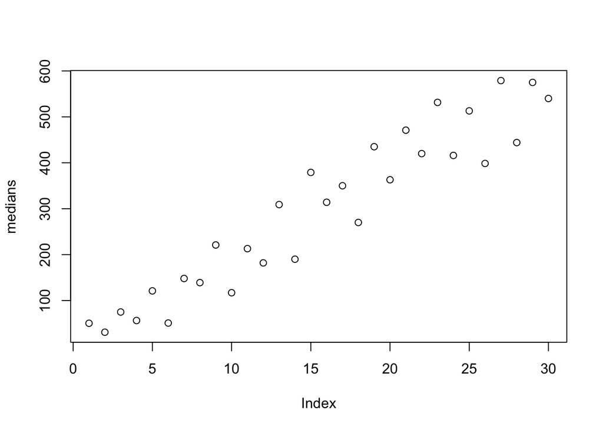

```r
plot(medians)
```

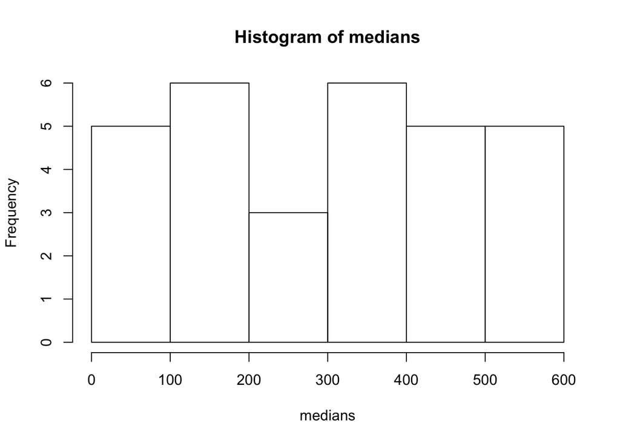

```r
hist(medians)
```

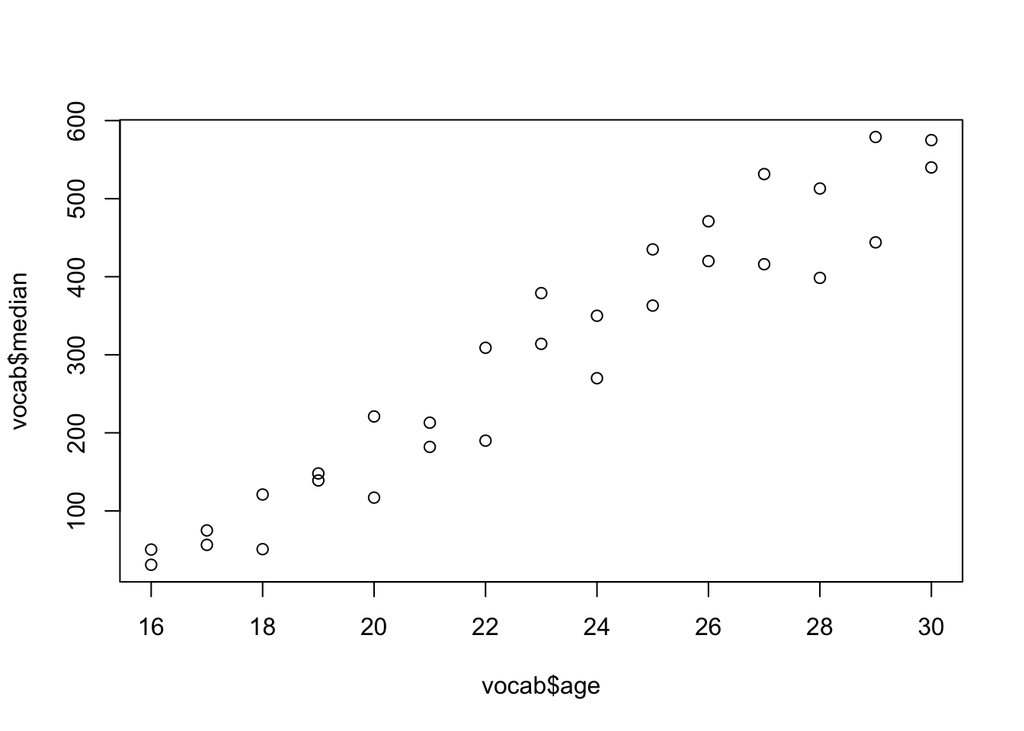

```r
plot(vocab$age, vocab$median)
```

…but I prefer using ggplot2 which gives us more intuitive options for visualization and greater control over the appearance:

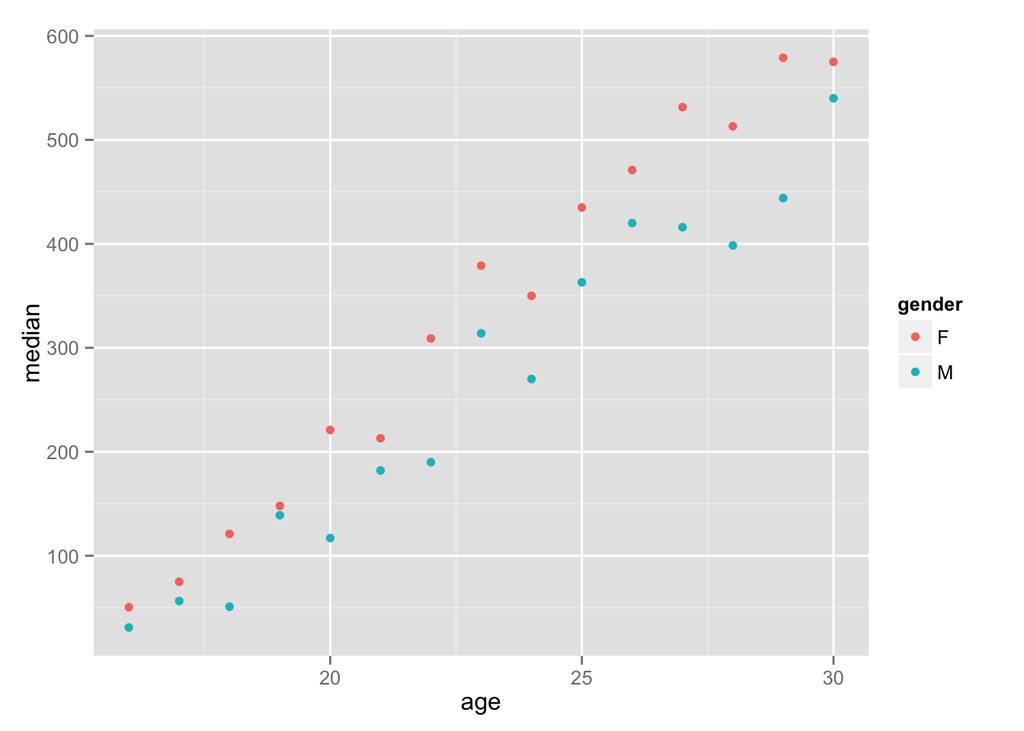

```r
ggplot(vocab, aes(x=age, y=median, color=gender)) +
                          geom_point()
```

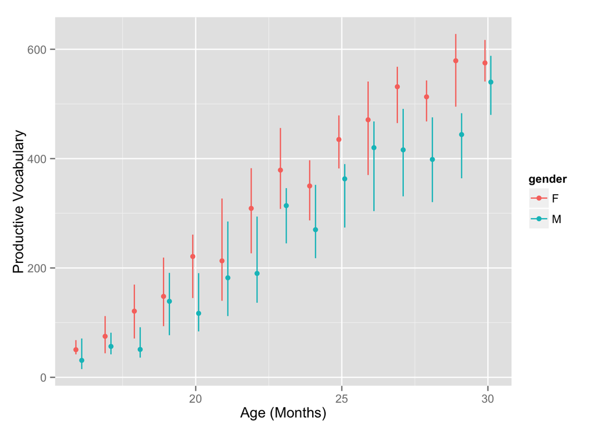

```r
ggplot(vocab, aes(x=age, y=median, color=gender)) +
        geom_pointrange(aes(min=median-ci.l, max=median+ci.h), position=position_dodge(.4)) +
        scale_x_continuous(name="Age (Months)") +
        scale_y_continuous(name="Productive Vocabulary")
```

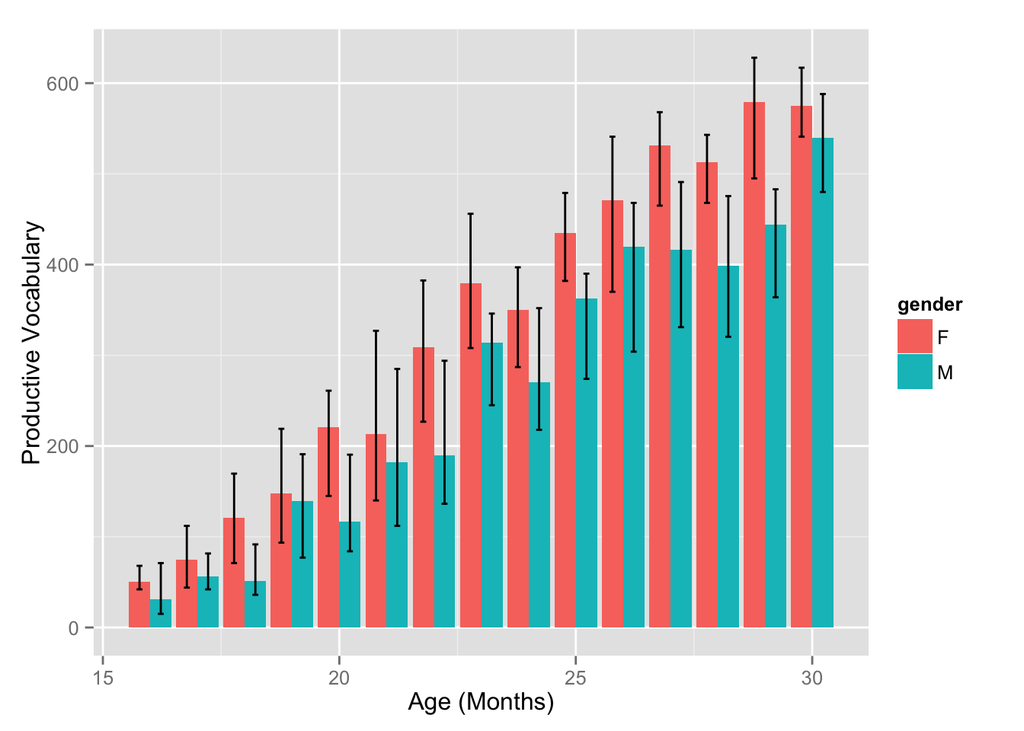

```r
ggplot(vocab, aes(x=age, y=median, fill=gender)) +
        geom_bar(stat='identity', position=position_dodge()) +
        geom_errorbar(aes(ymax=median+ci.h, ymin=median-ci.l), position=position_dodge(.9), width=0.25) +
        scale_x_continuous(name="Age (Months)") +
        scale_y_continuous(name="Productive Vocabulary")
```

We’ll gradually use more and more advanced aspects of ggplot throughout these tutorials. For now, we are simply plotting single variables from a dataframe (much like we could with Excel). However, by the 4th tutorial, we’ll be using ggplot to group, transform, and summarize our (almost) raw data and visualize it in a single shot.

# Statistical tests and models

Finally, R provides a host of functions to run statistical tests and/or fit models to your data.

Let’s do a basic correlation just to see how these functions work.

First, get just the female data:

```r
female_vocab <- vocab[which(vocab$gender == 'F'), c('age','median')]
female_vocab
```

```
##    age median
## 1   16   50.5
## 3   17   75.0
## 5   18  121.0
## 7   19  148.0
## 9   20  221.0
## 11  21  213.0
## 13  22  309.0
## 15  23  379.0
## 17  24  350.0
## 19  25  435.0
## 21  26  471.0
## 23  27  531.5
## 25  28  513.0
## 27  29  579.0
## 29  30  575.0
```

## Does age correlate with productive vocabulary?

Plot using basic R plots.

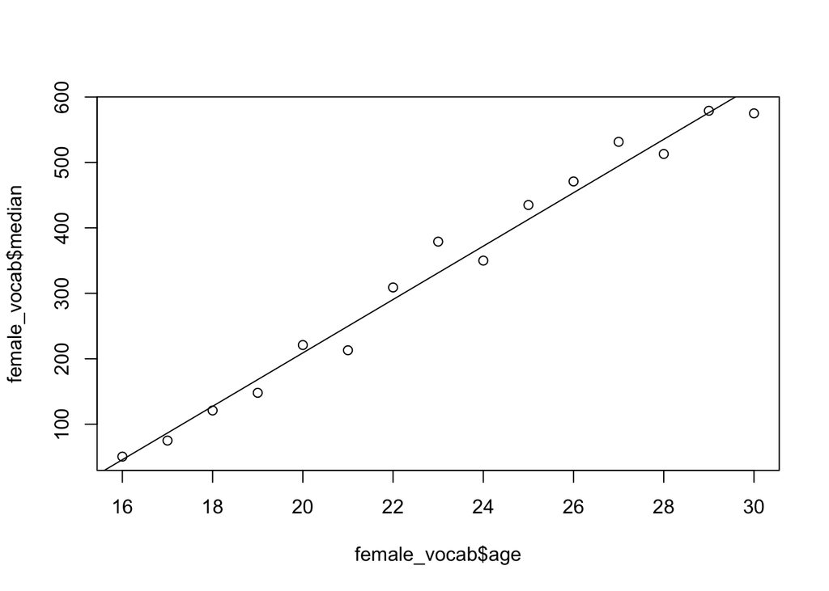

```r
plot(female_vocab$age, female_vocab$median)

# add a line of best fit
abline(lm(female_vocab$median ~ female_vocab$age))
```

We’ll get more into the syntax of `lm()` later, but this function uses a linear model to predict the ‘median’ vector from the ‘age’ vector, then feeds this to `abline()` to plot this line of best fit.

We can do the same thing with ggplot, though it is nice enough to give us the SE around our linear model fit:

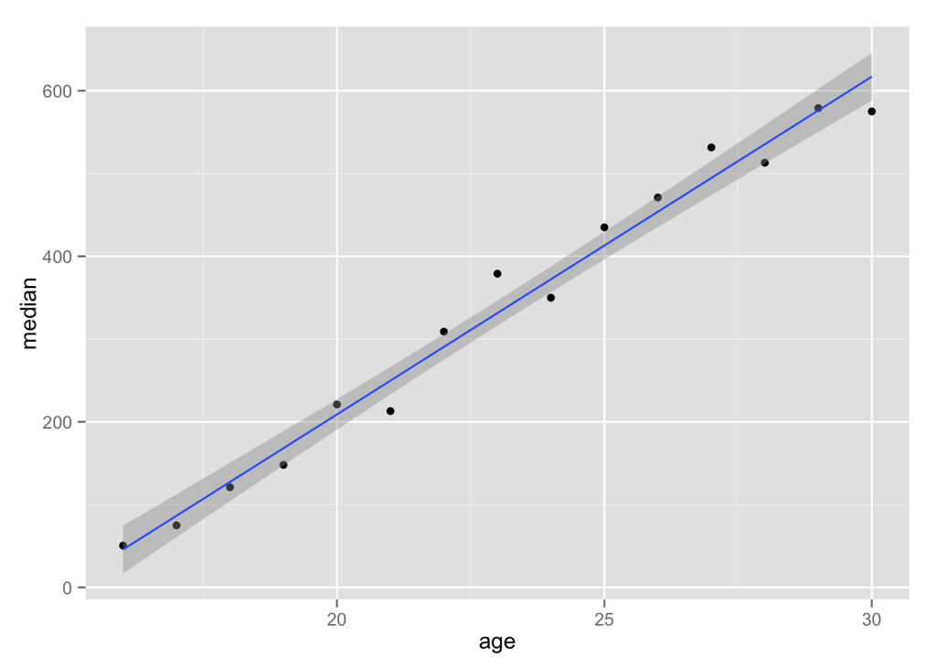

```r
ggplot(female_vocab, aes(x=age, y=median)) +
                                  geom_point() +
                                  stat_smooth(method="lm")
```

What is the Pearson’s r for this correlation?

```r
cor(female_vocab$age, female_vocab$median)
```

```
## [1] 0.9898423
```

Is this significant?

```r
cor.test(female_vocab$age, female_vocab$median)
```

```
##
##  Pearson's product-moment correlation
##
## data:  female_vocab$age and female_vocab$median
## t = 25.1033, df = 13, p-value = 2.123e-12
## alternative hypothesis: true correlation is not equal to 0
## 95 percent confidence interval:
##  0.9688378 0.9967126
## sample estimates:
##       cor
## 0.9898423
```

We can access specific variables in this statistical test’s output directly:

```r
cor_output <- cor.test(female_vocab$age, female_vocab$median)

# useful command to show the available data in any variable
str(cor_output)
```

```
## List of 9
##  $ statistic  : Named num 25.1
##   ..- attr(*, "names")= chr "t"
##  $ parameter  : Named int 13
##   ..- attr(*, "names")= chr "df"
##  $ p.value    : num 2.12e-12
##  $ estimate   : Named num 0.99
##   ..- attr(*, "names")= chr "cor"
##  $ null.value : Named num 0
##   ..- attr(*, "names")= chr "correlation"
##  $ alternative: chr "two.sided"
##  $ method     : chr "Pearson's product-moment correlation"
##  $ data.name  : chr "female_vocab$age and female_vocab$median"
##  $ conf.int   : atomic [1:2] 0.969 0.997
##   ..- attr(*, "conf.level")= num 0.95
##  - attr(*, "class")= chr "htest"
```

```r
cor_output$p.value
```

```
## [1] 2.123191e-12
```

```r
cor_output$statistic
```

```
##        t
## 25.10328
```

```r
# also:
names(cor_output)
```

```
## [1] "statistic"   "parameter"   "p.value"     "estimate"    "null.value"
## [6] "alternative" "method"      "data.name"   "conf.int"
```

```r
cor_output$conf.int
```

```
## [1] 0.9688378 0.9967126
## attr(,"conf.level")
## [1] 0.95
```

```r
# round the p-value:
cor_output$p.value
```

```
## [1] 2.123191e-12
```

```r
round(cor_output$p.value, 3)
```

```
## [1] 0
```

```r
# how much variance does this account for (e.g., R-squared, R^2)?
cor_output$estimate^2
```

```
##       cor
## 0.9797878
```

When we run statistical models, the vector we return is not only a collection of variables (e.g., from which we can select the p-value, estimate, etc.) but also an *object* on which we can run various *class* methods.

```r
class(cor_output)
```

```
## [1] "htest"
```

Here we can see we have an “htest” (i.e., “hypothesis test”) object.

This class is limited to the “print” method.

```r
print(cor_output)
```

```
##
##  Pearson's product-moment correlation
##
## data:  female_vocab$age and female_vocab$median
## t = 25.1033, df = 13, p-value = 2.123e-12
## alternative hypothesis: true correlation is not equal to 0
## 95 percent confidence interval:
##  0.9688378 0.9967126
## sample estimates:
##       cor
## 0.9898423
```

… but other classes include other methods like ‘plot’, ‘summary’, etc.

Let’s run another statistical test on some random data. A Welch’s t-test:

```r
t.test(rnorm(30,5,5), rnorm(30,10,5))
```

```
##
##  Welch Two Sample t-test
##
## data:  rnorm(30, 5, 5) and rnorm(30, 10, 5)
## t = -4.8836, df = 55.798, p-value = 9.129e-06
## alternative hypothesis: true difference in means is not equal to 0
## 95 percent confidence interval:
##  -9.210762 -3.852051
## sample estimates:
## mean of x mean of y
##  3.713278 10.244684
```

We can pass specific options to these tests. One common option for ‘t.test’ is var.equal=T so that we run a standard Student t-test rather than a Welch’s t-test.

```r
t.test(rnorm(30,5,5), rnorm(30,10,5), var.equal=T)
```

```
##
##  Two Sample t-test
##
## data:  rnorm(30, 5, 5) and rnorm(30, 10, 5)
## t = -3.8627, df = 58, p-value = 0.0002851
## alternative hypothesis: true difference in means is not equal to 0
## 95 percent confidence interval:
##  -7.656380 -2.429654
## sample estimates:
## mean of x mean of y
##  4.921633  9.964650
```

We can also use `paired` to run a dependent, paired t-test, or use `alt` to specify whether we want a one-sided or two-sided p-value.

```r
t.test(rnorm(30,5,5), rnorm(30,10,5), paired=T)
```

```
##
##  Paired t-test
##
## data:  rnorm(30, 5, 5) and rnorm(30, 10, 5)
## t = -3.1272, df = 29, p-value = 0.003993
## alternative hypothesis: true difference in means is not equal to 0
## 95 percent confidence interval:
##  -6.334596 -1.325091
## sample estimates:
## mean of the differences
##               -3.829843
```

```r
t.test(rnorm(30,5,5), rnorm(30,10,5), alt='less',var.equal=T) # by default: 'two.sided'
```

```
##
##  Two Sample t-test
##
## data:  rnorm(30, 5, 5) and rnorm(30, 10, 5)
## t = -3.0536, df = 58, p-value = 0.001706
## alternative hypothesis: true difference in means is less than 0
## 95 percent confidence interval:
##      -Inf -1.66684
## sample estimates:
## mean of x mean of y
##  6.669842 10.352722
```

What class is a `t.test()` object?

```r
class(t.test(rnorm(30,5,5), rnorm(30,10,5), var.equal=T))
```

```
## [1] "htest"
```

It’s the same as `cor.test()`, which is why the output is similar.

Finally, we loaded our data from a CSV, now let’s save a dataset to a CSV file.

```r
write.csv(female_vocab, 'data-vocab-females.csv')
```

Clean up our workspace.

```r
ls()
```

```
## [1] "cor_output"   "female_vocab" "medians"      "vocab"
## [5] "z_scores"
```

```r
rm(list=ls())
```